# WilloughbyHW6

Bryant Willoughby

2025-10-24

# Problem 1

Description: In a study of cheddar cheese, samples of cheese were analyzed for their chemical composition and were subjected to taste tests. Overall taste scores were obtained by combining the scores from several tasters. This is a data frame with 30 observations on four variables.

```r
# help(cheddar)
data(cheddar)
head(cheddar)
```

|  | taste | Acetic | H2S | Lactic |
| --- | --- | --- | --- | --- |
| 1 | 12.3 | 4.543 | 3.135 | 0.86 |
| 2 | 20.9 | 5.159 | 5.043 | 1.53 |
| 3 | 39.0 | 5.366 | 5.438 | 1.57 |
| 4 | 47.9 | 5.759 | 7.496 | 1.81 |
| 5 | 5.6 | 4.663 | 3.807 | 0.99 |
| 6 | 25.9 | 5.697 | 7.601 | 1.09 |

Using the `cheddar` data, fit a linear model with `taste` as the response and the other three variables as predictors.

```r
model.OLS <- lm(taste ~ ., data = cheddar)
summary(model.OLS)
```

```
##
## Call:
## lm(formula = taste ~ ., data = cheddar)
##
## Residuals:
##     Min      1Q  Median      3Q     Max
## -17.390  -6.612  -1.009   4.908  25.449
##
## Coefficients:
##             Estimate Std. Error t value Pr(>|t|)
## (Intercept) -28.8768    19.7354  -1.463  0.15540
## Acetic        0.3277     4.4598   0.073  0.94198
## H2S           3.9118     1.2484   3.133  0.00425 **
## Lactic       19.6705     8.6291   2.280  0.03108 *
## ---
## Signif. codes:  0 '***' 0.001 '**' 0.01 '*' 0.05 '.' 0.1 ' ' 1
##
## Residual standard error: 10.13 on 26 degrees of freedom
## Multiple R-squared:  0.6518, Adjusted R-squared:  0.6116
## F-statistic: 16.22 on 3 and 26 DF,  p-value: 3.81e-06
```

- Suppose that the observations were taken in time order. Create a time variable. Plot the residuals of the model against time and comment on what can be seen.

```r
time.var <- 1:nrow(cheddar)
cheddar <- cbind(cheddar, time.var)
head(cheddar)
```

|  | taste | Acetic | H2S | Lactic | time.var |
| --- | --- | --- | --- | --- | --- |
| 1 | 12.3 | 4.543 | 3.135 | 0.86 | 1 |
| 2 | 20.9 | 5.159 | 5.043 | 1.53 | 2 |
| 3 | 39.0 | 5.366 | 5.438 | 1.57 | 3 |
| 4 | 47.9 | 5.759 | 7.496 | 1.81 | 4 |
| 5 | 5.6 | 4.663 | 3.807 | 0.99 | 5 |
| 6 | 25.9 | 5.697 | 7.601 | 1.09 | 6 |

Notice how the residuals are decreasing linearly over time. This gives visual (informal) evidence to suggest that the errors (residuals) are correlated over time, violating one of the OLS assumptions.

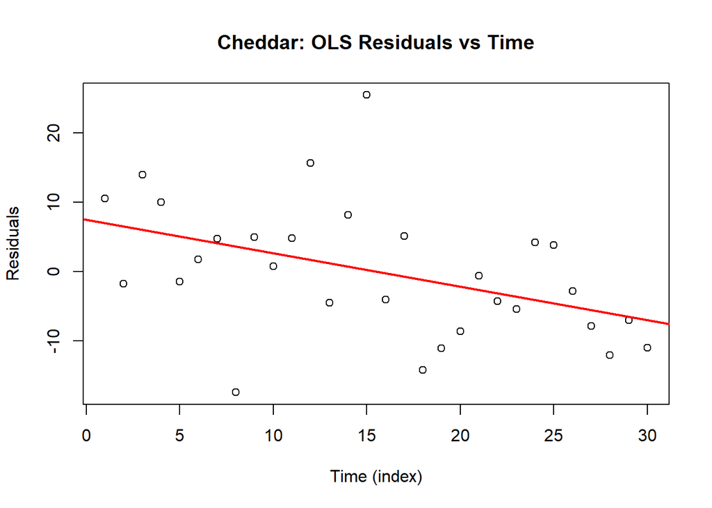

```r
plot(time.var, model.OLS$residuals,
     main = "Cheddar: OLS Residuals vs Time",
     xlab = "Time (index)",
     ylab = "Residuals")
abline(lm(resid(model.OLS) ~ time.var, data = cheddar), col = "red", lwd = 2)
```

- Fit a GLS model with same form as above but now allow for an AR(1) correlation among the errors. Is there evidence of such a correlation?

```r
model.GLS <- gls(taste ~ Acetic + H2S + Lactic,
                 correlation = corAR1(form = ~ time.var),
                 data = cheddar)
summary(model.GLS)
```

```
## Generalized least squares fit by REML
##   Model: taste ~ Acetic + H2S + Lactic
##   Data: cheddar
##      AIC      BIC  logLik
##   214.94 222.4886 -101.47
##
## Correlation Structure: AR(1)
##  Formula: ~time.var
##  Parameter estimate(s):
##       Phi
## 0.2641944
##
## Coefficients:
##                  Value Std.Error   t-value p-value
## (Intercept) -30.332472 20.273077 -1.496195  0.1466
## Acetic        1.436411  4.876581  0.294553  0.7707
## H2S           4.058880  1.314283  3.088284  0.0047
## Lactic       15.826468  9.235404  1.713674  0.0985
##
##  Correlation:
##        (Intr) Acetic H2S
## Acetic -0.899
## H2S     0.424 -0.395
## Lactic  0.063 -0.416 -0.435
##
## Standardized residuals:
##         Min          Q1         Med          Q3         Max
## -1.64546468 -0.63861716 -0.06641714  0.52255676  2.41323020
##
## Residual standard error: 10.33276
## Degrees of freedom: 30 total; 26 residual
```

Under the autoregressive model as seen above, $\rho$ is used to test correlated errors. Formally, we are testing $H_o: \rho = 0 \text{ vs } H_a: \rho \ne 0$. Assuming this test uses the $\alpha = 0.05$ significance level, we can use a $100(1 - (\alpha = 0.05)) = 95\%$ confidence level to address the same statistical question. That is, the below $95\%$ CI for $\rho$ contains zero. Thus, we fail to reject $H_o$ and there is not significant evidence to suggest the errors are correlated.

```r
intervals(model.GLS)
```

```
## Approximate 95% confidence intervals
##
##  Coefficients:
##                  lower       est.     upper
## (Intercept) -72.004379 -30.332472 11.339436
## Acetic       -8.587544   1.436411 11.460367
## H2S           1.357332   4.058880  6.760427
## Lactic       -3.157177  15.826468 34.810113
##
##  Correlation structure:
##          lower      est.     upper
## Phi -0.1691951 0.2641944 0.6119685
##
##  Residual standard error:
##     lower      est.     upper
##  7.626295 10.332756 13.999701
```

- Fit a OLS model but now with time as an additional predictor. Investigate the significance of time in the model.

In the following OLS model, `H2S` and `Lactic` are significant predictors, as was seen in the original OLS model above. Now, the manually constructed `time.var` is also significant in this model. That suggests there is an additional time component that is missing in the original OLS model.

```r
model.OLS.time <- lm(taste ~ ., data = cheddar)
summary(model.OLS.time)
```

```
##
## Call:
## lm(formula = taste ~ ., data = cheddar)
##
## Residuals:
##      Min       1Q   Median       3Q      Max
## -22.3523  -4.9735  -0.5089   4.8531  23.1311
##
## Coefficients:
##             Estimate Std. Error t value Pr(>|t|)
## (Intercept) -36.6127    17.9845  -2.036  0.05250 .
## Acetic        4.1275     4.2556   0.970  0.34139
## H2S           3.5387     1.1315   3.127  0.00444 **
## Lactic       17.9527     7.7875   2.305  0.02973 *
## time.var     -0.5459     0.2043  -2.672  0.01306 *
## ---
## Signif. codes:  0 '***' 0.001 '**' 0.01 '*' 0.05 '.' 0.1 ' ' 1
##
## Residual standard error: 9.112 on 25 degrees of freedom
## Multiple R-squared:  0.7291, Adjusted R-squared:  0.6858
## F-statistic: 16.83 on 4 and 25 DF,  p-value: 8.205e-07
```

- The last two models have both allowed for an effect of time. Explain how they do this differently.

The GLS model treats time as a source of autocorrelation in the residuals, whereas the OLS model treats time as an explicit predictor influencing the mean response. Since these reflect different mechanisms, it is possible to find a significant time trend in the mean (OLS + time) even when the estimated residual correlation parameter $\rho$ from the GLS model is not significant. This suggests that the apparent time pattern in the residual plot likely reflects a systematic trend in taste over time rather than serially correlated random fluctuations (errors depend on previous errors even after controlling for predictors).

# Problem 2

Using the `sat` data, fit a model with `total` as the response and `takers`, `ratio`, `salary` and `expend` as predictors using the following methods:

Description: The `sat` data frame has 50 rows and 7 columns. Data were collected to study the relationship between expenditures on public education and test results.

```r
# help(sat)
data(sat)
head(sat)
```

|  | expend | ratio | salary | takers | verbal | math | total |
| --- | --- | --- | --- | --- | --- | --- | --- |
| Alabama | 4.405 | 17.2 | 31.144 | 8 | 491 | 538 | 1029 |
| Alaska | 8.963 | 17.6 | 47.951 | 47 | 445 | 489 | 934 |
| Arizona | 4.778 | 19.3 | 32.175 | 27 | 448 | 496 | 944 |
| Arkansas | 4.459 | 17.1 | 28.934 | 6 | 482 | 523 | 1005 |
| California | 4.992 | 24.0 | 41.078 | 45 | 417 | 485 | 902 |
| Colorado | 5.443 | 18.4 | 34.571 | 29 | 462 | 518 | 980 |

- Ordinary least squares

I consult the p-values here to assess significance of predictors in the model.

```r
model.OLS <- lm(total ~ takers + ratio + salary + expend, data = sat)
summary(model.OLS)
```

```
##
## Call:
## lm(formula = total ~ takers + ratio + salary + expend, data = sat)
##
## Residuals:
##     Min      1Q  Median      3Q     Max
## -90.531 -20.855  -1.746  15.979  66.571
##
## Coefficients:
##              Estimate Std. Error t value Pr(>|t|)
## (Intercept) 1045.9715    52.8698  19.784  < 2e-16 ***
## takers        -2.9045     0.2313 -12.559 2.61e-16 ***
## ratio         -3.6242     3.2154  -1.127    0.266
## salary         1.6379     2.3872   0.686    0.496
## expend         4.4626    10.5465   0.423    0.674
## ---
## Signif. codes:  0 '***' 0.001 '**' 0.01 '*' 0.05 '.' 0.1 ' ' 1
##
## Residual standard error: 32.7 on 45 degrees of freedom
## Multiple R-squared:  0.8246, Adjusted R-squared:  0.809
## F-statistic: 52.88 on 4 and 45 DF,  p-value: < 2.2e-16
```

- Least absolute deviations

I consult the confidence intervals to assess significance in the predictors. Since the same significance level ($\alpha = 0.05$) is being used, a CI excluding zero provides evidence for a signifcant predictor.

```r
model.LAD <- rq(total ~ takers + ratio + salary + expend, data = sat)
summary(model.LAD)
```

```
##
## Call: rq(formula = total ~ takers + ratio + salary + expend, data = sat)
##
## tau: [1] 0.5
##
## Coefficients:
##             coefficients lower bd   upper bd
## (Intercept) 1090.89886    920.17149 1151.85075
## takers        -3.13961     -3.38485   -2.66479
## ratio         -7.26632    -10.73796    1.62341
## salary         3.18313     -0.15788    5.41909
## expend        -0.79753     -8.88001   20.92522
```

- Huber’s robust regression

```r
round(qt(0.025, df = 45, lower.tail = F),3)
```

```
## [1] 2.014
```

A predictor is significant if its respective t-test statistic has the following property: $|t| \gt 2.014$

```r
model.HM <- rlm(total ~ takers + ratio + salary + expend, data = sat)
summary(model.HM)
```

```
##
## Call: rlm(formula = total ~ takers + ratio + salary + expend, data = sat)
## Residuals:
##     Min      1Q  Median      3Q     Max
## -92.510 -17.701  -1.002  15.015  77.058
##
## Coefficients:
##             Value     Std. Error t value
## (Intercept) 1060.2074   49.8845    21.2533
## takers        -2.9778    0.2182   -13.6470
## ratio         -5.1254    3.0339    -1.6894
## salary         2.0933    2.2525     0.9293
## expend         3.9158    9.9510     0.3935
##
## Residual standard error: 25.58 on 45 degrees of freedom
```

Compare the results. In each case, comment on the significance of predictors.

Across all three regression methods: ordinary least squares (OLS), least absolute deviations (LAD), and Huber’s robust regression, `takers` emerges as a consistently significant predictor of total SAT score at the $\alpha=0.05$. None of the other predictors reach statistical significance across all models, suggesting that the proportion of test takers is the most stable and influential variable in explaining variation in SAT performance.

The sign reversal of the `expend` coefficient in the LAD model may suggest that a few high-expenditure states exert substantial influence in the OLS and Huber fits, pulling their coefficients positive. Because LAD regression minimizes absolute rather than squared residuals, it is less sensitive to such extreme values, so its negative coefficient could reflect the trend among the majority of observations rather than the influence of outliers. However, this interpretation should be made cautiously; additional diagnostic plots (e.g., residual vs. leverage, influence measures) would be needed to confirm whether specific high-expenditure states are truly driving the difference.

```r
coef(model.OLS)
```

```
## (Intercept)      takers       ratio      salary      expend
## 1045.971536   -2.904481   -3.624232    1.637917    4.462594
```

```r
coef(model.LAD)
```

```
##  (Intercept)       takers        ratio       salary       expend
## 1090.8988638   -3.1396146   -7.2663187    3.1831325   -0.7975319
```

```r
coef(model.HM)
```

```
## (Intercept)      takers       ratio      salary      expend
## 1060.207357   -2.977805   -5.125365    2.093258    3.915810
```